# Optimal Treatment Analysis

## Outcome Variable

**Outcome Variable:** haz

## Predictor Variables

**Intervention Variable:** impfloor

**Adjustment Set:**

- arm
- sex
- W_mage
- meducyrs
- feducyrs
- hhwealth_quart
- hfoodsec
- W_mhtcm
- W_mwtkg
- W_mbmi
- W_nrooms
- W_nchldlt5
- W_parity
- impsan
- safeh20
- delta_W_mage
- delta_meducyrs
- delta_feducyrs
- delta_hhwealth_quart
- delta_hfoodsec
- delta_W_mhtcm
- delta_W_mwtkg
- delta_W_mbmi
- delta_W_nrooms
- delta_W_nchldlt5
- delta_W_parity
- delta_impsan
- delta_safeh20

## Stratifying Variables

The analysis was stratified on these variable(s):

- agecat
- studyid
- country

## Data Summary

| agecat | studyid | country | impfloor | n_cell | n |
| --- | --- | --- | --- | --- | --- |
| Birth | ki0047075b-MAL-ED | BANGLADESH | 1 | 196 | 213 |
| Birth | ki0047075b-MAL-ED | BANGLADESH | 0 | 17 | 213 |
| Birth | ki0047075b-MAL-ED | BRAZIL | 1 | 58 | 60 |
| Birth | ki0047075b-MAL-ED | BRAZIL | 0 | 2 | 60 |
| Birth | ki0047075b-MAL-ED | INDIA | 1 | 35 | 41 |
| Birth | ki0047075b-MAL-ED | INDIA | 0 | 6 | 41 |
| Birth | ki0047075b-MAL-ED | NEPAL | 1 | 9 | 25 |
| Birth | ki0047075b-MAL-ED | NEPAL | 0 | 16 | 25 |
| Birth | ki0047075b-MAL-ED | PERU | 1 | 39 | 215 |
| Birth | ki0047075b-MAL-ED | PERU | 0 | 176 | 215 |
| Birth | ki0047075b-MAL-ED | SOUTH AFRICA | 1 | 87 | 96 |
| Birth | ki0047075b-MAL-ED | SOUTH AFRICA | 0 | 9 | 96 |
| Birth | ki0047075b-MAL-ED | TANZANIA, UNITED REPUBLIC OF | 1 | 7 | 119 |
| Birth | ki0047075b-MAL-ED | TANZANIA, UNITED REPUBLIC OF | 0 | 112 | 119 |
| Birth | ki1000108-CMC-V-BCS-2002 | INDIA | 1 | 72 | 72 |
| Birth | ki1000108-CMC-V-BCS-2002 | INDIA | 0 | 0 | 72 |
| Birth | ki1000108-IRC | INDIA | 1 | 287 | 287 |
| Birth | ki1000108-IRC | INDIA | 0 | 0 | 287 |
| Birth | ki1017093-NIH-Birth | BANGLADESH | 1 | 533 | 605 |
| Birth | ki1017093-NIH-Birth | BANGLADESH | 0 | 72 | 605 |
| Birth | ki1017093b-PROVIDE | BANGLADESH | 1 | 491 | 539 |
| Birth | ki1017093b-PROVIDE | BANGLADESH | 0 | 48 | 539 |
| Birth | ki1017093c-NIH-Crypto | BANGLADESH | 1 | 558 | 732 |
| Birth | ki1017093c-NIH-Crypto | BANGLADESH | 0 | 174 | 732 |
| Birth | ki1113344-GMS-Nepal | NEPAL | 1 | 100 | 544 |
| Birth | ki1113344-GMS-Nepal | NEPAL | 0 | 444 | 544 |
| Birth | ki1114097-CONTENT | PERU | 1 | 2 | 2 |
| Birth | ki1114097-CONTENT | PERU | 0 | 0 | 2 |
| Birth | kiGH5241-JiVitA-3 | BANGLADESH | 1 | 2064 | 26604 |
| Birth | kiGH5241-JiVitA-3 | BANGLADESH | 0 | 24540 | 26604 |

[output cut: 66 more lines]

The following strata were considered:

- agecat: 24 months, studyid: ki0047075b-MAL-ED, country: BANGLADESH
- agecat: 24 months, studyid: ki0047075b-MAL-ED, country: BRAZIL
- agecat: 24 months, studyid: ki0047075b-MAL-ED, country: INDIA
- agecat: 24 months, studyid: ki0047075b-MAL-ED, country: NEPAL
- agecat: 24 months, studyid: ki0047075b-MAL-ED, country: PERU
- agecat: 24 months, studyid: ki0047075b-MAL-ED, country: SOUTH AFRICA
- agecat: 24 months, studyid: ki0047075b-MAL-ED, country: TANZANIA, UNITED REPUBLIC OF
- agecat: 24 months, studyid: ki1000108-CMC-V-BCS-2002, country: INDIA
- agecat: 24 months, studyid: ki1000108-IRC, country: INDIA
- agecat: 24 months, studyid: ki1017093-NIH-Birth, country: BANGLADESH
- agecat: 24 months, studyid: ki1017093b-PROVIDE, country: BANGLADESH
- agecat: 24 months, studyid: ki1017093c-NIH-Crypto, country: BANGLADESH
- agecat: 24 months, studyid: ki1113344-GMS-Nepal, country: NEPAL
- agecat: 24 months, studyid: ki1114097-CONTENT, country: PERU
- agecat: 24 months, studyid: kiGH5241-JiVitA-3, country: BANGLADESH
- agecat: 24 months, studyid: kiGH5241-JiVitA-4, country: BANGLADESH
- agecat: 6 months, studyid: ki0047075b-MAL-ED, country: BANGLADESH
- agecat: 6 months, studyid: ki0047075b-MAL-ED, country: BRAZIL
- agecat: 6 months, studyid: ki0047075b-MAL-ED, country: INDIA
- agecat: 6 months, studyid: ki0047075b-MAL-ED, country: NEPAL
- agecat: 6 months, studyid: ki0047075b-MAL-ED, country: PERU
- agecat: 6 months, studyid: ki0047075b-MAL-ED, country: SOUTH AFRICA
- agecat: 6 months, studyid: ki0047075b-MAL-ED, country: TANZANIA, UNITED REPUBLIC OF
- agecat: 6 months, studyid: ki1000108-CMC-V-BCS-2002, country: INDIA
- agecat: 6 months, studyid: ki1000108-IRC, country: INDIA
- agecat: 6 months, studyid: ki1017093-NIH-Birth, country: BANGLADESH
- agecat: 6 months, studyid: ki1017093b-PROVIDE, country: BANGLADESH
- agecat: 6 months, studyid: ki1017093c-NIH-Crypto, country: BANGLADESH
- agecat: 6 months, studyid: ki1113344-GMS-Nepal, country: NEPAL
- agecat: 6 months, studyid: ki1114097-CONTENT, country: PERU
- agecat: 6 months, studyid: kiGH5241-JiVitA-3, country: BANGLADESH
- agecat: 6 months, studyid: kiGH5241-JiVitA-4, country: BANGLADESH
- agecat: Birth, studyid: ki0047075b-MAL-ED, country: BANGLADESH
- agecat: Birth, studyid: ki0047075b-MAL-ED, country: BRAZIL
- agecat: Birth, studyid: ki0047075b-MAL-ED, country: INDIA
- agecat: Birth, studyid: ki0047075b-MAL-ED, country: NEPAL
- agecat: Birth, studyid: ki0047075b-MAL-ED, country: PERU
- agecat: Birth, studyid: ki0047075b-MAL-ED, country: SOUTH AFRICA
- agecat: Birth, studyid: ki0047075b-MAL-ED, country: TANZANIA, UNITED REPUBLIC OF
- agecat: Birth, studyid: ki1000108-CMC-V-BCS-2002, country: INDIA
- agecat: Birth, studyid: ki1000108-IRC, country: INDIA
- agecat: Birth, studyid: ki1017093-NIH-Birth, country: BANGLADESH
- agecat: Birth, studyid: ki1017093b-PROVIDE, country: BANGLADESH
- agecat: Birth, studyid: ki1017093c-NIH-Crypto, country: BANGLADESH
- agecat: Birth, studyid: ki1113344-GMS-Nepal, country: NEPAL
- agecat: Birth, studyid: ki1114097-CONTENT, country: PERU
- agecat: Birth, studyid: kiGH5241-JiVitA-3, country: BANGLADESH
- agecat: Birth, studyid: kiGH5241-JiVitA-4, country: BANGLADESH

### Dropped Strata

- agecat: Birth, studyid: ki0047075b-MAL-ED, country: BRAZIL
- agecat: Birth, studyid: ki1000108-CMC-V-BCS-2002, country: INDIA
- agecat: Birth, studyid: ki1000108-IRC, country: INDIA
- agecat: Birth, studyid: ki1114097-CONTENT, country: PERU
- agecat: 6 months, studyid: ki0047075b-MAL-ED, country: BRAZIL
- agecat: 6 months, studyid: ki1000108-CMC-V-BCS-2002, country: INDIA
- agecat: 6 months, studyid: ki1000108-IRC, country: INDIA
- agecat: 24 months, studyid: ki0047075b-MAL-ED, country: BRAZIL
- agecat: 24 months, studyid: ki1000108-CMC-V-BCS-2002, country: INDIA
- agecat: 24 months, studyid: ki1000108-IRC, country: INDIA

## Methods Detail

We’re interested in the causal parameters $E[Y_a]$ for all values of $a \in \mathcal{A}$. These parameters represent the mean outcome if, possibly contrary to fact, we intervened to set all units to have $A=a$. Under the randomization and positivity assumptions, these are identified by the statistical parameters $\psi_a=E_W[E_{Y|A,W}(Y|A=a,W)]$. In addition, we’re interested in the mean of $Y$, $E[Y]$ under no intervention (the observed mean). We will estimate these parameters by using SuperLearner to fit the relevant likelihood factors – $E_{Y|A,W}(Y|A=a,W)$ and $p(A=a|W)$, and then updating our likelihood fit using a joint TMLE.

For unadjusted analyses ($W=\{\}$), initial likelihoods were estimated using Lrnr_glm to estimate the simple $E(Y|A)$ and Lrnr_mean to estimate $p(A)$. For adjusted analyses, a small library containing Lrnr_glmnet, Lrnr_xgboost, and Lrnr_mean was used.

Having estimated these parameters, we will then use the delta method to estimate relative risks and attributable risks relative to a prespecified baseline level of $A$.

# Results Detail

## Results Plots

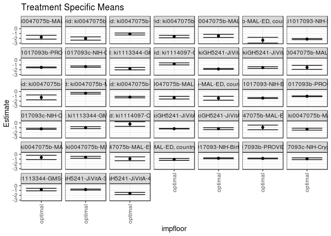

## Results Table

### Parameter: TSM

| agecat | studyid | country | intervention_level | baseline_level | estimate | ci_lower | ci_upper |
| --- | --- | --- | --- | --- | --- | --- | --- |
| Birth | ki0047075b-MAL-ED | BANGLADESH | optimal | observed | -0.9405809 | -1.4248821 | -0.4562797 |
| Birth | ki0047075b-MAL-ED | INDIA | optimal | observed | -1.3002344 | -1.5001559 | -1.1003129 |
| Birth | ki0047075b-MAL-ED | NEPAL | optimal | observed | -0.6536915 | -1.1014977 | -0.2058853 |
| Birth | ki0047075b-MAL-ED | PERU | optimal | observed | -0.6240136 | -0.8251765 | -0.4228507 |
| Birth | ki0047075b-MAL-ED | SOUTH AFRICA | optimal | observed | -0.9331332 | -1.3315721 | -0.5346943 |
| Birth | ki0047075b-MAL-ED | TANZANIA, UNITED REPUBLIC OF | optimal | observed | -1.0730700 | -1.2741725 | -0.8719674 |
| Birth | ki1017093-NIH-Birth | BANGLADESH | optimal | observed | -0.8260164 | -0.9195782 | -0.7324545 |
| Birth | ki1017093b-PROVIDE | BANGLADESH | optimal | observed | -0.8633320 | -0.9422852 | -0.7843789 |
| Birth | ki1017093c-NIH-Crypto | BANGLADESH | optimal | observed | -0.9279623 | -1.1144287 | -0.7414959 |
| Birth | ki1113344-GMS-Nepal | NEPAL | optimal | observed | -0.8106296 | -1.0765353 | -0.5447238 |
| Birth | kiGH5241-JiVitA-3 | BANGLADESH | optimal | observed | -0.8041092 | -0.9108360 | -0.6973823 |
| Birth | kiGH5241-JiVitA-4 | BANGLADESH | optimal | observed | -1.6132732 | -1.8319654 | -1.3945811 |
| 6 months | ki0047075b-MAL-ED | BANGLADESH | optimal | observed | -1.5139900 | -1.9341048 | -1.0938753 |
| 6 months | ki0047075b-MAL-ED | INDIA | optimal | observed | -1.2299419 | -1.7359535 | -0.7239303 |
| 6 months | ki0047075b-MAL-ED | NEPAL | optimal | observed | -0.3685147 | -0.5287501 | -0.2082793 |
| 6 months | ki0047075b-MAL-ED | PERU | optimal | observed | -1.1625738 | -1.3106298 | -1.0145178 |
| 6 months | ki0047075b-MAL-ED | SOUTH AFRICA | optimal | observed | -1.2894174 | -1.5731460 | -1.0056887 |
| 6 months | ki0047075b-MAL-ED | TANZANIA, UNITED REPUBLIC OF | optimal | observed | -1.3982855 | -1.8044962 | -0.9920749 |
| 6 months | ki1017093-NIH-Birth | BANGLADESH | optimal | observed | -1.3710980 | -1.4656807 | -1.2765152 |
| 6 months | ki1017093b-PROVIDE | BANGLADESH | optimal | observed | -0.9962040 | -1.0763506 | -0.9160574 |
| 6 months | ki1017093c-NIH-Crypto | BANGLADESH | optimal | observed | -1.2335516 | -1.3571395 | -1.1099637 |
| 6 months | ki1113344-GMS-Nepal | NEPAL | optimal | observed | -0.9857892 | -1.1922540 | -0.7793244 |
| 6 months | ki1114097-CONTENT | PERU | optimal | observed | -0.2396104 | -0.7342761 | 0.2550552 |
| 6 months | kiGH5241-JiVitA-3 | BANGLADESH | optimal | observed | -1.2049967 | -1.2643006 | -1.1456928 |
| 6 months | kiGH5241-JiVitA-4 | BANGLADESH | optimal | observed | -1.1988672 | -1.3979952 | -0.9997392 |
| 24 months | ki0047075b-MAL-ED | BANGLADESH | optimal | observed | -1.7677156 | -2.1739493 | -1.3614819 |
| 24 months | ki0047075b-MAL-ED | INDIA | optimal | observed | -2.0398042 | -2.3752002 | -1.7044082 |
| 24 months | ki0047075b-MAL-ED | NEPAL | optimal | observed | -1.1021792 | -1.3066477 | -0.8977107 |
| 24 months | ki0047075b-MAL-ED | PERU | optimal | observed | -1.6305196 | -1.8908880 | -1.3701513 |
| 24 months | ki0047075b-MAL-ED | SOUTH AFRICA | optimal | observed | -1.5023771 | -1.8332696 | -1.1714846 |
| 24 months | ki0047075b-MAL-ED | TANZANIA, UNITED REPUBLIC OF | optimal | observed | -2.3934940 | -2.9876161 | -1.7993719 |
| 24 months | ki1017093-NIH-Birth | BANGLADESH | optimal | observed | -2.1577982 | -2.2659771 | -2.0496193 |
| 24 months | ki1017093b-PROVIDE | BANGLADESH | optimal | observed | -1.5196774 | -1.6084757 | -1.4308791 |
| 24 months | ki1017093c-NIH-Crypto | BANGLADESH | optimal | observed | -1.3564711 | -1.4904248 | -1.2225174 |
| 24 months | ki1113344-GMS-Nepal | NEPAL | optimal | observed | -1.7828798 | -2.0355657 | -1.5301939 |
| 24 months | ki1114097-CONTENT | PERU | optimal | observed | -0.7844211 | -0.9977785 | -0.5710636 |
| 24 months | kiGH5241-JiVitA-3 | BANGLADESH | optimal | observed | -1.8464823 | -1.9383813 | -1.7545833 |
| 24 months | kiGH5241-JiVitA-4 | BANGLADESH | optimal | observed | -1.5560588 | -1.7438373 | -1.3682803 |

### Parameter: E(Y)

| agecat | studyid | country | intervention_level | baseline_level | estimate | ci_lower | ci_upper |
| --- | --- | --- | --- | --- | --- | --- | --- |
| Birth | ki0047075b-MAL-ED | BANGLADESH | observed | observed | -1.0530516 | -1.1896058 | -0.9164975 |
| Birth | ki0047075b-MAL-ED | INDIA | observed | observed | -1.2070732 | -1.5254820 | -0.8886644 |
| Birth | ki0047075b-MAL-ED | NEPAL | observed | observed | -0.7828000 | -1.1547571 | -0.4108429 |
| Birth | ki0047075b-MAL-ED | PERU | observed | observed | -0.9141395 | -1.0364098 | -0.7918693 |
| Birth | ki0047075b-MAL-ED | SOUTH AFRICA | observed | observed | -0.5523958 | -0.7550074 | -0.3497843 |
| Birth | ki0047075b-MAL-ED | TANZANIA, UNITED REPUBLIC OF | observed | observed | -1.1213445 | -1.3341800 | -0.9085090 |
| Birth | ki1017093-NIH-Birth | BANGLADESH | observed | observed | -0.9289256 | -1.0178691 | -0.8399821 |
| Birth | ki1017093b-PROVIDE | BANGLADESH | observed | observed | -0.8851020 | -0.9601332 | -0.8100709 |
| Birth | ki1017093c-NIH-Crypto | BANGLADESH | observed | observed | -0.9094945 | -0.9809370 | -0.8380521 |
| Birth | ki1113344-GMS-Nepal | NEPAL | observed | observed | -1.1177022 | -1.2075344 | -1.0278700 |
| Birth | kiGH5241-JiVitA-3 | BANGLADESH | observed | observed | -1.1725229 | -1.2005540 | -1.1444918 |
| Birth | kiGH5241-JiVitA-4 | BANGLADESH | observed | observed | -1.5236135 | -1.5727559 | -1.4744711 |
| 6 months | ki0047075b-MAL-ED | BANGLADESH | observed | observed | -1.2031806 | -1.3209873 | -1.0853738 |
| 6 months | ki0047075b-MAL-ED | INDIA | observed | observed | -1.2069078 | -1.3255669 | -1.0882487 |
| 6 months | ki0047075b-MAL-ED | NEPAL | observed | observed | -0.5534934 | -0.6683107 | -0.4386762 |
| 6 months | ki0047075b-MAL-ED | PERU | observed | observed | -1.3293333 | -1.4383829 | -1.2202838 |
| 6 months | ki0047075b-MAL-ED | SOUTH AFRICA | observed | observed | -1.0554016 | -1.1850591 | -0.9257441 |
| 6 months | ki0047075b-MAL-ED | TANZANIA, UNITED REPUBLIC OF | observed | observed | -1.3700408 | -1.4930436 | -1.2470380 |
| 6 months | ki1017093-NIH-Birth | BANGLADESH | observed | observed | -1.4060639 | -1.4948910 | -1.3172368 |
| 6 months | ki1017093b-PROVIDE | BANGLADESH | observed | observed | -1.0916915 | -1.1661176 | -1.0172654 |
| 6 months | ki1017093c-NIH-Crypto | BANGLADESH | observed | observed | -1.1986783 | -1.2700937 | -1.1272630 |
| 6 months | ki1113344-GMS-Nepal | NEPAL | observed | observed | -1.3225094 | -1.4115793 | -1.2334396 |
| 6 months | ki1114097-CONTENT | PERU | observed | observed | -0.3139217 | -0.4868486 | -0.1409948 |
| 6 months | kiGH5241-JiVitA-3 | BANGLADESH | observed | observed | -1.3358555 | -1.3589365 | -1.3127744 |
| 6 months | kiGH5241-JiVitA-4 | BANGLADESH | observed | observed | -1.3440174 | -1.3812821 | -1.3067527 |
| 24 months | ki0047075b-MAL-ED | BANGLADESH | observed | observed | -1.9789151 | -2.1055330 | -1.8522972 |
| 24 months | ki0047075b-MAL-ED | INDIA | observed | observed | -1.8848458 | -2.0096941 | -1.7599975 |
| 24 months | ki0047075b-MAL-ED | NEPAL | observed | observed | -1.2972172 | -1.4192878 | -1.1751466 |
| 24 months | ki0047075b-MAL-ED | PERU | observed | observed | -1.7544776 | -1.8753255 | -1.6336298 |
| 24 months | ki0047075b-MAL-ED | SOUTH AFRICA | observed | observed | -1.6491807 | -1.7842885 | -1.5140729 |
| 24 months | ki0047075b-MAL-ED | TANZANIA, UNITED REPUBLIC OF | observed | observed | -2.6428302 | -2.7790815 | -2.5065788 |
| 24 months | ki1017093-NIH-Birth | BANGLADESH | observed | observed | -2.2235968 | -2.3265592 | -2.1206344 |
| 24 months | ki1017093b-PROVIDE | BANGLADESH | observed | observed | -1.6024221 | -1.6857420 | -1.5191023 |
| 24 months | ki1017093c-NIH-Crypto | BANGLADESH | observed | observed | -1.4412646 | -1.5249156 | -1.3576135 |
| 24 months | ki1113344-GMS-Nepal | NEPAL | observed | observed | -1.8396747 | -1.9349390 | -1.7444104 |
| 24 months | ki1114097-CONTENT | PERU | observed | observed | -0.6962195 | -0.8674103 | -0.5250287 |
| 24 months | kiGH5241-JiVitA-3 | BANGLADESH | observed | observed | -2.0193889 | -2.0469721 | -1.9918057 |
| 24 months | kiGH5241-JiVitA-4 | BANGLADESH | observed | observed | -1.7804046 | -1.8159135 | -1.7448956 |

### Parameter: PAR

| agecat | studyid | country | intervention_level | baseline_level | estimate | ci_lower | ci_upper |
| --- | --- | --- | --- | --- | --- | --- | --- |
| Birth | ki0047075b-MAL-ED | BANGLADESH | optimal | observed | -0.1124708 | -0.5749940 | 0.3500525 |
| Birth | ki0047075b-MAL-ED | INDIA | optimal | observed | 0.0931612 | -0.2613202 | 0.4476427 |
| Birth | ki0047075b-MAL-ED | NEPAL | optimal | observed | -0.1291085 | -0.4392947 | 0.1810777 |
| Birth | ki0047075b-MAL-ED | PERU | optimal | observed | -0.2901260 | -0.4516140 | -0.1286379 |
| Birth | ki0047075b-MAL-ED | SOUTH AFRICA | optimal | observed | 0.3807373 | 0.0089101 | 0.7525646 |
| Birth | ki0047075b-MAL-ED | TANZANIA, UNITED REPUBLIC OF | optimal | observed | -0.0482746 | -0.1471444 | 0.0505953 |
| Birth | ki1017093-NIH-Birth | BANGLADESH | optimal | observed | -0.1029092 | -0.1480345 | -0.0577840 |
| Birth | ki1017093b-PROVIDE | BANGLADESH | optimal | observed | -0.0217700 | -0.0438146 | 0.0002746 |
| Birth | ki1017093c-NIH-Crypto | BANGLADESH | optimal | observed | 0.0184678 | -0.1448807 | 0.1818162 |
| Birth | ki1113344-GMS-Nepal | NEPAL | optimal | observed | -0.3070726 | -0.5669079 | -0.0472374 |
| Birth | kiGH5241-JiVitA-3 | BANGLADESH | optimal | observed | -0.3684138 | -0.4713678 | -0.2654597 |
| Birth | kiGH5241-JiVitA-4 | BANGLADESH | optimal | observed | 0.0896598 | -0.1170803 | 0.2963998 |
| 6 months | ki0047075b-MAL-ED | BANGLADESH | optimal | observed | 0.3108095 | -0.0799903 | 0.7016092 |
| 6 months | ki0047075b-MAL-ED | INDIA | optimal | observed | 0.0230341 | -0.4651351 | 0.5112034 |
| 6 months | ki0047075b-MAL-ED | NEPAL | optimal | observed | -0.1849787 | -0.3128100 | -0.0571475 |
| 6 months | ki0047075b-MAL-ED | PERU | optimal | observed | -0.1667595 | -0.2737155 | -0.0598035 |
| 6 months | ki0047075b-MAL-ED | SOUTH AFRICA | optimal | observed | 0.2340158 | -0.0301646 | 0.4981961 |
| 6 months | ki0047075b-MAL-ED | TANZANIA, UNITED REPUBLIC OF | optimal | observed | 0.0282447 | -0.3690356 | 0.4255250 |
| 6 months | ki1017093-NIH-Birth | BANGLADESH | optimal | observed | -0.0349659 | -0.0659644 | -0.0039675 |
| 6 months | ki1017093b-PROVIDE | BANGLADESH | optimal | observed | -0.0954875 | -0.1381650 | -0.0528100 |
| 6 months | ki1017093c-NIH-Crypto | BANGLADESH | optimal | observed | 0.0348733 | -0.0561649 | 0.1259115 |
| 6 months | ki1113344-GMS-Nepal | NEPAL | optimal | observed | -0.3367203 | -0.5366051 | -0.1368355 |
| 6 months | ki1114097-CONTENT | PERU | optimal | observed | -0.0743113 | -0.5369564 | 0.3883339 |
| 6 months | kiGH5241-JiVitA-3 | BANGLADESH | optimal | observed | -0.1308587 | -0.1903776 | -0.0713399 |
| 6 months | kiGH5241-JiVitA-4 | BANGLADESH | optimal | observed | -0.1451502 | -0.3385994 | 0.0482990 |
| 24 months | ki0047075b-MAL-ED | BANGLADESH | optimal | observed | -0.2111995 | -0.6048020 | 0.1824030 |
| 24 months | ki0047075b-MAL-ED | INDIA | optimal | observed | 0.1549583 | -0.1441164 | 0.4540331 |
| 24 months | ki0047075b-MAL-ED | NEPAL | optimal | observed | -0.1950380 | -0.3484408 | -0.0416351 |
| 24 months | ki0047075b-MAL-ED | PERU | optimal | observed | -0.1239580 | -0.3449241 | 0.0970081 |
| 24 months | ki0047075b-MAL-ED | SOUTH AFRICA | optimal | observed | -0.1468035 | -0.4704405 | 0.1768334 |
| 24 months | ki0047075b-MAL-ED | TANZANIA, UNITED REPUBLIC OF | optimal | observed | -0.2493361 | -0.8332255 | 0.3345532 |
| 24 months | ki1017093-NIH-Birth | BANGLADESH | optimal | observed | -0.0657986 | -0.1051801 | -0.0264172 |
| 24 months | ki1017093b-PROVIDE | BANGLADESH | optimal | observed | -0.0827448 | -0.1238006 | -0.0416889 |
| 24 months | ki1017093c-NIH-Crypto | BANGLADESH | optimal | observed | -0.0847935 | -0.1903532 | 0.0207662 |
| 24 months | ki1113344-GMS-Nepal | NEPAL | optimal | observed | -0.0567949 | -0.3030491 | 0.1894593 |
| 24 months | ki1114097-CONTENT | PERU | optimal | observed | 0.0882016 | -0.0183827 | 0.1947858 |
| 24 months | kiGH5241-JiVitA-3 | BANGLADESH | optimal | observed | -0.1729066 | -0.2648247 | -0.0809885 |
| 24 months | kiGH5241-JiVitA-4 | BANGLADESH | optimal | observed | -0.2243458 | -0.4061415 | -0.0425500 |